# Ford GoBike System (Lyft) Data Project

### Project # 5 - Data Visualization

By Edwin Aquino  
June 26, 2019

- Introduction
- Part I - Gathering Data
- Part II - Assessing Data
- Part III - Cleaning Data
- Part IV - Univariate Exploration
- Part V- Bivariate Exploration
- Part VI- Multivariate Exploration
- Conclusions
- Resources

### Introduction

In this project, we will be gathering data from the Ford GoBike System. The goal for this project is to wrangle Ford GoBike System Data to create interesting and trustworthy analyses and visualizations.

This data set includes information about individual rides made in a bike-sharing system covering the greater San Francisco Bay area.

On this data set we will be doing some data wrangling in order to make it tidy for analysis. There are multiple cities covered by the linked Ford GoBike System, and multiple data files will be joined together to compile all of 2017 & 2018.

This project is divided into two major parts. In the first part, we will conduct an exploratory data analysis on a dataset. We will using Python data science and data visualization libraries to explore the dataset’s variables and understand the data’s structure, oddities, patterns and relationships. The analysis in this part will be structured, going from simple univariate relationships up through multivariate relationships. This project is our opportunity to ask questions of the data and make our own discoveries.

In the second part, we will take our main findings from this exploration and convey them to others through an explanatory analysis. To this end, we will create a slide deck that leverages polished, explanatory visualizations to communicate our results. This part of the project will make heavy use of the first part of the project. We will select one or two major paths in our exploration, choosing relevant visualizations along that path, and then polish them to construct a story for readers to understand what we found.

## Part I - Gathering Data

Go Back To The Top

Gathering Data for this Project will involved the following:

1. The Ford GoBike System Data is hosted at the Udacity servers and the all the files will be downloaded programmatically using the Requests library from the following URL: https://s3.amazonaws.com/fordgobike-data/index.html
2. The download files are available in zip format. Therefore, we will programmatically extract the .csv files from the zip files and placed them in a separate directory within this project's directory.
3. Once all the csv files have been downloaded and extracted, we will combine all the files into one data frame.

**Start: Import the required libraries.**

```python
# Include required libraries for this project
from os import path, getcwd, makedirs, listdir
from io import BytesIO # for zip files
from zipfile import ZipFile
import pandas as pd
import numpy as np
import matplotlib
from matplotlib import pyplot as plt
import matplotlib.ticker as tick
import seaborn as sns
import datetime
import time
import calendar
import warnings
import requests
from pathlib import Path
#warnings.filterwarnings('ignore') - only show errors
from IPython.display import Image
%matplotlib inline
import warnings
warnings.filterwarnings('ignore')
# Display progress bar
from ipywidgets import FloatProgress
from IPython.display import display, clear_output
```

```python
files_url = 'https://s3.amazonaws.com/fordgobike-data/'
# Directory of all the csv data files will be contained
csv_files_dir = 'data_files/'
if path.exists(csv_files_dir):
    print('Directory "'+csv_files_dir+'" Already Exists') # If directory already exists, nothing to do
else:
    makedirs(csv_files_dir)
    print('Directory Created Successfully')
```

```
Directory "data_files/" Already Exists
```

```python
# Download and save the 2017 dataset large file:
# programmatically download using pandas the data set file 2017-fordgobike-tripdata.csv
filename = '2017-fordgobike-tripdata.csv'
filePath = csv_files_dir+filename
# check if file already exists, if already exists do nothing.
#https://stackoverflow.com/questions/82831/how-do-i-check-whether-a-file-exists-without-exceptions
if path.exists(filePath):
    print("[OK] File ", filePath, ' was previously downloaded')
else:
    file_url = files_url + filename
    print("File Name: '"+filePath+"' does not exist in this project.\nDownloading file: ", filename, " - Please wait...", end='\r')
    results = requests.get(file_url)
    with open(csv_files_dir+file_url.split('/')[-1], mode = 'wb') as outfile:
        if outfile.write(results.content):
            print("[Download Complete] File: " + filename + " ", end='\r')
```

```
[OK] File  data_files/2017-fordgobike-tripdata.csv  was previously downloaded
```

```python
# Downad all the 2018 zip files and extract the csv files to the data directory:
for month in range(1,13):
    month_string = str(month)
    # [MONTH] wil be replaced by the numerical month
    fileName = '2018[MONTH]-fordgobike-tripdata'
    month_leading_zero = month_string.zfill(2)
    fileName = fileName.replace("[MONTH]", month_leading_zero)

    csvFileName = fileName+ '.csv'
    zipFileName = fileName+'.csv.zip'

    # check if file already exists
    #https://stackoverflow.com/questions/82831/how-do-i-check-whether-a-file-exists-without-exceptions
    if path.exists(csv_files_dir+csvFileName):
        print("[OK] File ", csvFileName, ' was previously downloaded')
    else:
        b = "Downloading... " + "" + csvFileName
        print (b, end="\r")
        time.sleep(1)
        #bike_data_url = 'https://s3.amazonaws.com/fordgobike-data/2018' + month_leading_zero + '-fordgobike-tripdata.csv.zip'
        file_url = files_url + zipFileName
        response = requests.get(file_url)
        # code below opens zip file; BytesIO returns a readable and writeable view of the contents;
        unzipped_file = ZipFile(BytesIO(response.content))
        # place extracted zip file into the data_files directory
        unzipped_file.extractall(csv_files_dir)
        print("[Completed]")
print('** Files Completed **')
```

```
[OK] File  201801-fordgobike-tripdata.csv  was previously downloaded
[OK] File  201802-fordgobike-tripdata.csv  was previously downloaded
[OK] File  201803-fordgobike-tripdata.csv  was previously downloaded
[OK] File  201804-fordgobike-tripdata.csv  was previously downloaded
[OK] File  201805-fordgobike-tripdata.csv  was previously downloaded
[OK] File  201806-fordgobike-tripdata.csv  was previously downloaded
[OK] File  201807-fordgobike-tripdata.csv  was previously downloaded
[OK] File  201808-fordgobike-tripdata.csv  was previously downloaded
[OK] File  201809-fordgobike-tripdata.csv  was previously downloaded
[OK] File  201810-fordgobike-tripdata.csv  was previously downloaded
[OK] File  201811-fordgobike-tripdata.csv  was previously downloaded
[OK] File  201812-fordgobike-tripdata.csv  was previously downloaded
** Files Completed **
```

```python
# set the CSV file name to be locally saved:
combined_csv_file_name = 'combined_data.csv'
```

```python
# Check if Combined Master File has already been created, if not, then created it Programmatically
if path.exists(csv_files_dir+combined_csv_file_name):
    print("[OK] Combined Master File ", csv_files_dir+combined_csv_file_name, ' was previously created.')
else:
    # Combine All Locally Saved CSVs into One DataFrame
    list_csvs = []
    month =1
    files = listdir(csv_files_dir)
    # https://stackoverflow.com/questions/38861829/how-do-i-implement-a-progress-bar
    f = FloatProgress(min=0, max=100)
    display(f)
    counter=0
    print('Combining all files into one Data Frame. Please wait...', end="\r")
    for file_name in files:
        #https://stackoverflow.com/questions/3964681/find-all-files-in-a-directory-with-extension-txt-in-python
        if file_name.endswith(".csv"):
            #print('[Combining File.....] ', file_name, end="\r")
            list_csvs.append(pd.read_csv(csv_files_dir+'/'+file_name))
            #print('[Combining Completed] ', file_name)
            counter +=1
            f.value += counter
    df = pd.concat(list_csvs)
    f.value += 100 # make bar fully complete
    print('[Complete] All files combined successfully into one DataFrame')
    # IF YOU GET ERROR: ParserError: Error tokenizing data. C error: Calling read(nbytes) on source failed. Try engine='python'.
    # SOLUTION: https://stackoverflow.com/questions/40835287/python-error-tokenizing-data-c-error-calling-readnbytes-on-source-failed-wi
```

```
[Complete] All files combined successfully into one DataFrame
```

```python
#Save the dataframe into one csv file
# Check if Combined Master File has already been created, if not, then created it Programmatically
if path.exists(csv_files_dir+combined_csv_file_name):
    print("[OK] Combined Master File ", csv_files_dir+combined_csv_file_name, ' was previously Saved.')
else:
    print('Saving ' + csv_files_dir+combined_csv_file_name + ' - This is a large DataFrame, This may take a while. Please wait...', end="\r", flush=True)
    df.to_csv(csv_files_dir+combined_csv_file_name)
    clear_output()
    print('[OK] File saved successfully as',csv_files_dir+combined_csv_file_name)
```

```
[OK] File saved successfully as data_files/combined_data.csv
```

```python
# Confirm the newly created dataframe is readable
# NOTE: file size is large (525MB) - This will that a while to load
start = time.time()
print('Loading DataFrame. This may take a while. Please Wait....', end="\r", flush=True)
df = pd.read_csv(csv_files_dir+combined_csv_file_name)
end = time.time()
exec_time = (end - start) / 60
clear_output()
print("[COMPLETE] DataFrame Has been Loaded Successfully\nTotal Execution Time: " +format(exec_time, '.0f') + " minutes")
```

```
[COMPLETE] DataFrame Has been Loaded Successfully
Total Execution Time: 0 minutes
```

```python
#confirm dataframe is available for analysing
len(df)
```

```
2383421
```

### Part I - Gathering Data - Summary

We have successfully completed the data wrangling process.

1. Programmatically download the required files
2. Combined all the files into one master file
3. Successful loaded the master dataframe

## Part II - Assessing Data

Go Back To The Top

Now that we have gathered our data, we will be assessing our data visually and programmatically to check for tidiness and quality. The goal of this process is to catch and document any quality or tidiness issues found in our data. These are some of areas we will be looking at:

#### Assessment:

1. Visually assess the dataset to catch any obvious issues.
2. Review a couple of random examples to check for anything suspicious
3. Assess the data programmatically

```python
# Visually assess the dataset to catch any obvious issues.
df
```

|  | Unnamed: 0 | bike_id | bike_share_for_all_trip | duration_sec | end_station_id | end_station_latitude | end_station_longitude | end_station_name | end_time | member_birth_year | member_gender | start_station_id | start_station_latitude | start_station_longitude | start_station_name | start_time | user_type |
| --- | --- | --- | --- | --- | --- | --- | --- | --- | --- | --- | --- | --- | --- | --- | --- | --- | --- |
| 0 | 0 | 2765 | No | 75284 | 285.0 | 37.783521 | -122.431158 | Webster St at O'Farrell St | 2018-02-01 19:47:19.8240 | 1986.0 | Male | 120.0 | 37.761420 | -122.426435 | Mission Dolores Park | 2018-01-31 22:52:35.2390 | Subscriber |
| 1 | 1 | 2815 | No | 85422 | 15.0 | 37.795392 | -122.394203 | San Francisco Ferry Building (Harry Bridges Pl... | 2018-02-01 15:57:17.3100 | NaN | NaN | 15.0 | 37.795392 | -122.394203 | San Francisco Ferry Building (Harry Bridges Pl... | 2018-01-31 16:13:34.3510 | Customer |
| 2 | 2 | 3039 | No | 71576 | 296.0 | 37.325998 | -121.877120 | 5th St at Virginia St | 2018-02-01 10:16:52.1160 | 1996.0 | Male | 304.0 | 37.348759 | -121.894798 | Jackson St at 5th St | 2018-01-31 14:23:55.8890 | Customer |
| 3 | 3 | 321 | No | 61076 | 47.0 | 37.780955 | -122.399749 | 4th St at Harrison St | 2018-02-01 07:51:20.5000 | NaN | NaN | 75.0 | 37.773793 | -122.421239 | Market St at Franklin St | 2018-01-31 14:53:23.5620 | Customer |
| 4 | 4 | 617 | No | 39966 | 19.0 | 37.788975 | -122.403452 | Post St at Kearny St | 2018-02-01 06:58:31.0530 | 1991.0 | Male | 74.0 | 37.776435 | -122.426244 | Laguna St at Hayes St | 2018-01-31 19:52:24.6670 | Subscriber |
| 5 | 5 | 1306 | No | 6477 | 160.0 | 37.805318 | -122.294837 | West Oakland BART Station | 2018-02-01 00:46:41.9080 | NaN | NaN | 236.0 | 37.803686 | -122.282497 | Market St at 8th St | 2018-01-31 22:58:44.8670 | Customer |
| 6 | 6 | 3571 | No | 453 | 134.0 | 37.752428 | -122.420628 | Valencia St at 24th St | 2018-02-01 00:01:26.8050 | 1988.0 | Male | 110.0 | 37.763708 | -122.415204 | 17th & Folsom Street Park (17th St at Folsom St) | 2018-01-31 23:53:53.6320 | Subscriber |
| 7 | 7 | 1403 | No | 180 | 93.0 | 37.770407 | -122.391198 | 4th St at Mission Bay Blvd S | 2018-01-31 23:55:10.8070 | 1980.0 | Male | 81.0 | 37.775880 | -122.393170 | Berry St at 4th St | 2018-01-31 23:52:09.9030 | Subscriber |
| 8 | 8 | 3675 | Yes | 996 | 4.0 | 37.785881 | -122.408915 | Cyril Magnin St at Ellis St | 2018-01-31 23:51:32.6740 | 1987.0 | Male | 134.0 | 37.752428 | -122.420628 | Valencia St at 24th St | 2018-01-31 23:34:56.0040 | Subscriber |
| 9 | 9 | 1453 | Yes | 825 | 317.0 | 37.333955 | -121.877349 | San Salvador St at 9th St | 2018-01-31 23:47:59.8090 | 1994.0 | Female | 305.0 | 37.342725 | -121.895617 | Ryland Park | 2018-01-31 23:34:14.0270 | Subscriber |
| 10 | 10 | 1278 | No | 1316 | 4.0 | 37.785881 | -122.408915 | Cyril Magnin St at Ellis St | 2018-01-31 23:45:56.8240 | NaN | NaN | 98.0 | 37.765052 | -122.421866 | Valencia St at 16th St | 2018-01-31 23:24:00.4160 | Customer |
| 11 | 11 | 2928 | No | 432 | 43.0 | 37.778768 | -122.415929 | San Francisco Public Library (Grove St at Hyde... | 2018-01-31 23:41:39.2970 | 1993.0 | Male | 89.0 | 37.769218 | -122.407646 | Division St at Potrero Ave | 2018-01-31 23:34:26.4840 | Subscriber |
| 12 | 12 | 3016 | No | 601 | 86.0 | 37.769305 | -122.426826 | Market St at Dolores St | 2018-01-31 23:39:48.0000 | 1957.0 | Male | 223.0 | 37.764765 | -122.420091 | 16th St Mission BART Station 2 | 2018-01-31 23:29:46.8320 | Subscriber |
| 13 | 13 | 55 | Yes | 887 | 297.0 | 37.322980 | -121.887931 | Locust St at Grant St | 2018-01-31 23:39:04.1230 | 1976.0 | Female | 308.0 | 37.336802 | -121.894090 | San Pedro Square | 2018-01-31 23:24:16.3570 | Subscriber |
| 14 | 14 | 2602 | No | 210 | 186.0 | 37.801319 | -122.262642 | Lakeside Dr at 14th St | 2018-01-31 23:36:33.7040 | 1976.0 | Male | 7.0 | 37.804562 | -122.271738 | Frank H Ogawa Plaza | 2018-01-31 23:33:03.0460 | Subscriber |
| 15 | 15 | 2556 | No | 188 | 76.0 | 37.771662 | -122.422423 | McCoppin St at Valencia St | 2018-01-31 23:34:06.3910 | 1964.0 | Female | 98.0 | 37.765052 | -122.421866 | Valencia St at 16th St | 2018-01-31 23:30:58.1360 | Subscriber |
| 16 | 16 | 3041 | Yes | 808 | 98.0 | 37.765052 | -122.421866 | Valencia St at 16th St | 2018-01-31 23:33:27.5310 | 1976.0 | Male | 67.0 | 37.776639 | -122.395526 | San Francisco Caltrain Station 2 (Townsend St... | 2018-01-31 23:19:58.6030 | Subscriber |
| 17 | 17 | 546 | No | 378 | 78.0 | 37.773717 | -122.411647 | Folsom St at 9th St | 2018-01-31 23:29:42.0440 | 1995.0 | Female | 80.0 | 37.775306 | -122.397380 | Townsend St at 5th St | 2018-01-31 23:23:23.0680 | Subscriber |
| 18 | 18 | 431 | No | 350 | 274.0 | 37.857567 | -122.267558 | Oregon St at Adeline St | 2018-01-31 23:19:36.2650 | NaN | NaN | 247.0 | 37.867789 | -122.265896 | Fulton St at Bancroft Way | 2018-01-31 23:13:45.5290 | Subscriber |
| 19 | 19 | 1886 | No | 686 | 317.0 | 37.333955 | -121.877349 | San Salvador St at 9th St | 2018-01-31 23:18:41.5580 | 1997.0 | Female | 312.0 | 37.329732 | -121.901782 | San Jose Diridon Station | 2018-01-31 23:07:15.3130 | Subscriber |
| 20 | 20 | 3583 | No | 450 | 157.0 | 37.846784 | -122.291376 | 65th St at Hollis St | 2018-01-31 23:14:43.8140 | 1994.0 | Male | 241.0 | 37.852477 | -122.270213 | Ashby BART Station | 2018-01-31 23:07:13.0630 | Subscriber |
| 21 | 21 | 2144 | No | 294 | 244.0 | 37.873792 | -122.268618 | Shattuck Ave at Hearst Ave | 2018-01-31 23:13:06.6360 | 1983.0 | Male | 239.0 | 37.868813 | -122.258764 | Bancroft Way at Telegraph Ave | 2018-01-31 23:08:12.0000 | Subscriber |
| 22 | 22 | 3468 | Yes | 150 | 183.0 | 37.808702 | -122.269927 | Telegraph Ave at 19th St | 2018-01-31 23:12:40.3330 | 1945.0 | Male | 182.0 | 37.809013 | -122.268247 | 19th Street BART Station | 2018-01-31 23:10:09.5860 | Subscriber |
| 23 | 23 | 1432 | Yes | 462 | 134.0 | 37.752428 | -122.420628 | Valencia St at 24th St | 2018-01-31 23:11:31.0290 | 1971.0 | Male | 119.0 | 37.761047 | -122.432642 | 18th St at Noe St | 2018-01-31 23:03:48.9400 | Subscriber |
| 24 | 24 | 997 | No | 379 | 189.0 | 37.839649 | -122.271756 | Genoa St at 55th St | 2018-01-31 23:10:46.9760 | 1975.0 | Male | 176.0 | 37.828410 | -122.266315 | MacArthur BART Station | 2018-01-31 23:04:27.7010 | Subscriber |
| 25 | 25 | 3725 | No | 880 | 145.0 | 37.743684 | -122.426806 | 29th St at Church St | 2018-01-31 23:08:21.4430 | 1986.0 | Male | 123.0 | 37.760594 | -122.414817 | Folsom St at 19th St | 2018-01-31 22:53:41.3020 | Subscriber |
| 26 | 26 | 1059 | No | 1210 | 133.0 | 37.755213 | -122.420975 | Valencia St at 22nd St | 2018-01-31 23:05:47.5760 | 1991.0 | Male | 285.0 | 37.783521 | -122.431158 | Webster St at O'Farrell St | 2018-01-31 22:45:37.1250 | Subscriber |
| 27 | 27 | 1208 | No | 259 | 266.0 | 37.862464 | -122.264791 | Parker St at Fulton St | 2018-01-31 23:05:32.1570 | 1994.0 | Male | 239.0 | 37.868813 | -122.258764 | Bancroft Way at Telegraph Ave | 2018-01-31 23:01:12.7920 | Subscriber |
| 28 | 28 | 1834 | No | 592 | 195.0 | 37.812314 | -122.260779 | Bay Pl at Vernon St | 2018-01-31 23:03:20.2900 | 1978.0 | Male | 202.0 | 37.800754 | -122.274894 | Washington St at 8th St | 2018-01-31 22:53:27.7790 | Customer |
| 29 | 29 | 1248 | No | 1059 | 79.0 | 37.773492 | -122.403672 | 7th St at Brannan St | 2018-01-31 23:02:56.2850 | 1988.0 | Male | 141.0 | 37.747998 | -122.420219 | Valencia St at Cesar Chavez St | 2018-01-31 22:45:16.5700 | Subscriber |
| ... | ... | ... | ... | ... | ... | ... | ... | ... | ... | ... | ... | ... | ... | ... | ... | ... | ... |
| 2383391 | 201428 | 4226 | No | 536 | 355.0 | 37.755367 | -122.388795 | 23rd St at Tennessee St | 2018-10-01 01:01:57.6350 | 1995.0 | Male | 139.0 | 37.751017 | -122.411901 | Garfield Square (25th St at Harrison St) | 2018-10-01 00:53:01.2580 | Subscriber |
| 2383392 | 201429 | 4410 | No | 853 | 3.0 | 37.786375 | -122.404904 | Powell St BART Station (Market St at 4th St) | 2018-10-01 00:59:08.8280 | 1993.0 | Male | 323.0 | 37.798014 | -122.405950 | Broadway at Kearny | 2018-10-01 00:44:55.3720 | Customer |
| 2383393 | 201430 | 4371 | No | 1011 | 3.0 | 37.786375 | -122.404904 | Powell St BART Station (Market St at 4th St) | 2018-10-01 00:59:01.6920 | 1986.0 | Male | 323.0 | 37.798014 | -122.405950 | Broadway at Kearny | 2018-10-01 00:42:10.4680 | Customer |
| 2383394 | 201431 | 3972 | No | 840 | 19.0 | 37.788975 | -122.403452 | Post St at Kearny St | 2018-10-01 00:55:44.6450 | 1991.0 | Male | 81.0 | 37.775880 | -122.393170 | Berry St at 4th St | 2018-10-01 00:41:44.2920 | Subscriber |
| 2383395 | 201432 | 447 | Yes | 266 | 243.0 | 37.869360 | -122.254337 | Bancroft Way at College Ave | 2018-10-01 00:55:13.8500 | 1994.0 | Male | 256.0 | 37.875112 | -122.260553 | Hearst Ave at Euclid Ave | 2018-10-01 00:50:47.2910 | Subscriber |
| 2383396 | 201433 | 1076 | No | 730 | 341.0 | 37.336188 | -121.889277 | Fountain Alley at S 2nd St | 2018-10-01 00:52:01.5910 | NaN | NaN | 341.0 | 37.336188 | -121.889277 | Fountain Alley at S 2nd St | 2018-10-01 00:39:50.8270 | Customer |
| 2383397 | 201434 | 955 | Yes | 229 | 18.0 | 37.850222 | -122.260172 | Telegraph Ave at Alcatraz Ave | 2018-10-01 00:47:11.4620 | 1989.0 | Male | 166.0 | 37.851376 | -122.252523 | College Ave at Alcatraz Ave | 2018-10-01 00:43:22.2470 | Subscriber |
| 2383398 | 201435 | 781 | No | 400 | 341.0 | 37.336188 | -121.889277 | Fountain Alley at S 2nd St | 2018-10-01 00:46:41.6030 | NaN | NaN | 341.0 | 37.336188 | -121.889277 | Fountain Alley at S 2nd St | 2018-10-01 00:40:01.1000 | Customer |
| 2383399 | 201436 | 2142 | Yes | 1255 | 7.0 | 37.804562 | -122.271738 | Frank H Ogawa Plaza | 2018-10-01 00:41:32.6820 | 1991.0 | Male | 236.0 | 37.803686 | -122.282497 | Market St at 8th St | 2018-10-01 00:20:37.1230 | Subscriber |
| 2383400 | 201437 | 4426 | No | 524 | 86.0 | 37.769305 | -122.426826 | Market St at Dolores St | 2018-10-01 00:41:11.3740 | 1967.0 | Male | 350.0 | 37.771431 | -122.405787 | 8th St at Brannan St | 2018-10-01 00:32:27.0060 | Subscriber |
| 2383401 | 201438 | 1326 | Yes | 273 | 226.0 | 37.781123 | -122.232991 | 26th Ave at International Blvd | 2018-10-01 00:40:47.2990 | 1989.0 | Male | 237.0 | 37.775232 | -122.224498 | Fruitvale BART Station | 2018-10-01 00:36:13.9880 | Subscriber |
| 2383402 | 201439 | 2880 | No | 282 | 269.0 | 37.862320 | -122.258801 | Telegraph Ave at Carleton St | 2018-10-01 00:39:44.2740 | 1994.0 | Male | 239.0 | 37.868813 | -122.258764 | Bancroft Way at Telegraph Ave | 2018-10-01 00:35:02.0960 | Subscriber |
| 2383403 | 201440 | 1250 | Yes | 167 | 247.0 | 37.867789 | -122.265896 | Fulton St at Bancroft Way | 2018-10-01 00:38:54.0950 | 1999.0 | Male | 258.0 | 37.872355 | -122.266447 | University Ave at Oxford St | 2018-10-01 00:36:06.1340 | Subscriber |
| 2383404 | 201441 | 4408 | No | 595 | 4.0 | 37.785881 | -122.408915 | Cyril Magnin St at Ellis St | 2018-10-01 00:37:07.8190 | 1988.0 | Male | 25.0 | 37.787522 | -122.397405 | Howard St at 2nd St | 2018-10-01 00:27:12.4030 | Subscriber |
| 2383405 | 201442 | 1421 | No | 199 | 4.0 | 37.785881 | -122.408915 | Cyril Magnin St at Ellis St | 2018-10-01 00:36:58.6790 | 1981.0 | Male | 44.0 | 37.781074 | -122.411738 | Civic Center/UN Plaza BART Station (Market St ... | 2018-10-01 00:33:38.7350 | Subscriber |
| 2383406 | 201443 | 3795 | No | 623 | 112.0 | 37.763847 | -122.413004 | Harrison St at 17th St | 2018-10-01 00:36:08.6380 | 1992.0 | Male | 33.0 | 37.781650 | -122.415408 | Golden Gate Ave at Hyde St | 2018-10-01 00:25:44.6680 | Subscriber |
| 2383407 | 201444 | 3087 | Yes | 1764 | 276.0 | 37.332233 | -121.912516 | Julian St at The Alameda | 2018-10-01 00:35:36.8070 | 1995.0 | Male | 276.0 | 37.332233 | -121.912516 | Julian St at The Alameda | 2018-10-01 00:06:12.2440 | Subscriber |
| 2383408 | 201445 | 4437 | No | 702 | 105.0 | 37.764285 | -122.431804 | 16th St at Prosper St | 2018-10-01 00:33:01.4890 | 1984.0 | Male | 5.0 | 37.783899 | -122.408445 | Powell St BART Station (Market St at 5th St) | 2018-10-01 00:21:18.7240 | Subscriber |
| 2383409 | 201446 | 955 | Yes | 643 | 166.0 | 37.851376 | -122.252523 | College Ave at Alcatraz Ave | 2018-10-01 00:32:33.6900 | 1989.0 | Male | 175.0 | 37.835946 | -122.262366 | 49th St at Telegraph Ave | 2018-10-01 00:21:49.7600 | Subscriber |
| 2383410 | 201447 | 845 | No | 692 | 324.0 | 37.788300 | -122.408531 | Union Square (Powell St at Post St) | 2018-10-01 00:32:29.8330 | 1975.0 | Male | 58.0 | 37.776619 | -122.417385 | Market St at 10th St | 2018-10-01 00:20:57.7850 | Subscriber |
| 2383411 | 201448 | 3532 | No | 1170 | 46.0 | 37.790140 | -122.242373 | San Antonio Park | 2018-10-01 00:29:03.8900 | 1982.0 | Male | 339.0 | 37.800002 | -122.266438 | Jackson St at 11th St | 2018-10-01 00:09:33.6620 | Subscriber |
| 2383412 | 201449 | 2428 | No | 455 | 81.0 | 37.775880 | -122.393170 | Berry St at 4th St | 2018-10-01 00:28:51.8030 | 1993.0 | Male | 126.0 | 37.761634 | -122.390648 | Esprit Park | 2018-10-01 00:21:15.8110 | Customer |
| 2383413 | 201450 | 3222 | No | 822 | 169.0 | 37.846516 | -122.265304 | Bushrod Park | 2018-10-01 00:27:01.8650 | 1985.0 | Male | 239.0 | 37.868813 | -122.258764 | Bancroft Way at Telegraph Ave | 2018-10-01 00:13:19.4690 | Subscriber |
| 2383414 | 201451 | 1546 | No | 936 | 214.0 | 37.823321 | -122.275733 | Market St at Brockhurst St | 2018-10-01 00:26:23.5650 | 1992.0 | Other | 195.0 | 37.812314 | -122.260779 | Bay Pl at Vernon St | 2018-10-01 00:10:47.4060 | Subscriber |
| 2383415 | 201452 | 3151 | Yes | 112 | 125.0 | 37.759200 | -122.409851 | 20th St at Bryant St | 2018-10-01 00:22:47.1640 | 1960.0 | Male | 113.0 | 37.764555 | -122.410345 | Franklin Square | 2018-10-01 00:20:54.6570 | Subscriber |
| 2383416 | 201453 | 652 | No | 534 | 84.0 | 37.769200 | -122.433812 | Duboce Park | 2018-10-01 00:22:09.4910 | 1963.0 | Male | 120.0 | 37.761420 | -122.426435 | Mission Dolores Park | 2018-10-01 00:13:15.0950 | Subscriber |
| 2383417 | 201454 | 4318 | No | 372 | 93.0 | 37.770407 | -122.391198 | 4th St at Mission Bay Blvd S | 2018-10-01 00:20:53.3650 | 1985.0 | Male | 102.0 | 37.766883 | -122.399579 | Irwin St at 8th St | 2018-10-01 00:14:41.2870 | Subscriber |
| 2383418 | 201455 | 3355 | No | 408 | 60.0 | 37.774520 | -122.409449 | 8th St at Ringold St | 2018-10-01 00:18:37.1800 | 1981.0 | Male | 4.0 | 37.785881 | -122.408915 | Cyril Magnin St at Ellis St | 2018-10-01 00:11:48.9960 | Subscriber |
| 2383419 | 201456 | 2549 | No | 75 | 37.0 | 37.785000 | -122.395936 | 2nd St at Folsom St | 2018-10-01 00:05:30.5080 | 1989.0 | Male | 343.0 | 37.783172 | -122.393572 | Bryant St at 2nd St | 2018-10-01 00:04:15.3520 | Subscriber |
| 2383420 | 201457 | 519 | No | 111 | 134.0 | 37.752428 | -122.420628 | Valencia St at 24th St | 2018-10-01 00:02:31.6260 | 1976.0 | Male | 132.0 | 37.751819 | -122.426614 | 24th St at Chattanooga St | 2018-10-01 00:00:40.4620 | Subscriber |

2383421 rows × 17 columns

```python
# Review a couple of random examples to check for anything suspicious
print(df['end_station_name'][548])
print(df['start_time'][712])
```

```
Shattuck Ave at 51st St
2018-01-31 18:47:48.7930
```

```python
# Assess the data programmatically - info()
df.info(verbose=True, null_counts=True)
```

```
RangeIndex: 2383421 entries, 0 to 2383420
Data columns (total 17 columns):
Unnamed: 0                 2383421 non-null int64
bike_id                    2383421 non-null int64
bike_share_for_all_trip    1863721 non-null object
duration_sec               2383421 non-null int64
end_station_id             2371650 non-null float64
end_station_latitude       2383421 non-null float64
end_station_longitude      2383421 non-null float64
end_station_name           2371650 non-null object
end_time                   2383421 non-null object
member_birth_year          2206162 non-null float64
member_gender              2206592 non-null object
start_station_id           2371650 non-null float64
start_station_latitude     2383421 non-null float64
start_station_longitude    2383421 non-null float64
start_station_name         2371650 non-null object
start_time                 2383421 non-null object
user_type                  2383421 non-null object
dtypes: float64(7), int64(3), object(7)
memory usage: 309.1+ MB
```

```python
# descriptive statistics for numeric variables
print(df.describe())
```

```
         Unnamed: 0       bike_id  duration_sec  end_station_id  \
count  2.383421e+06  2.383421e+06  2.383421e+06    2.371650e+06
mean   1.211889e+05  2.160719e+03  9.100063e+02    1.124780e+02
std    1.113442e+05  1.252545e+03  2.643865e+03    9.785323e+01
min    0.000000e+00  1.000000e+01  6.100000e+01    3.000000e+00
25%    4.583500e+04  1.119000e+03  3.570000e+02    2.900000e+01
50%    9.167000e+04  2.173000e+03  5.640000e+02    8.100000e+01
75%    1.539990e+05  3.116000e+03  8.850000e+02    1.800000e+02
max    5.196990e+05  6.234000e+03  8.636900e+04    3.810000e+02
       end_station_latitude  end_station_longitude  member_birth_year  \
count          2.383421e+06           2.383421e+06       2.206162e+06
mean           3.776798e+01          -1.223518e+02       1.982537e+03
std            1.017500e-01           1.541098e-01       1.051346e+01
min            3.726331e+01          -1.224737e+02       1.881000e+03
25%            3.777166e+01          -1.224094e+02       1.977000e+03
50%            3.778175e+01          -1.223971e+02       1.985000e+03
75%            3.779539e+01          -1.222948e+02       1.990000e+03
max            4.551000e+01          -7.357000e+01       2.000000e+03
       start_station_id  start_station_latitude  start_station_longitude
count      2.371650e+06            2.383421e+06             2.383421e+06
mean       1.142750e+02            3.776784e+01            -1.223524e+02
std        9.797252e+01            1.018623e-01             1.545178e-01
min        3.000000e+00            3.726331e+01            -1.224737e+02
25%        3.000000e+01            3.777106e+01            -1.224116e+02
50%        8.100000e+01            3.778127e+01            -1.223974e+02
75%        1.810000e+02            3.779539e+01            -1.222948e+02
max        3.810000e+02            4.551000e+01            -7.357000e+01
```

```python
# Assess the data programmatically
df['bike_id'].value_counts()
```

```
3961    1220
661     1189
126     1177
1161    1172
1738    1155
3105    1153
2174    1152
2545    1149
232     1148
1396    1146
2692    1145
4452    1141
2774    1136
2663    1131
746     1123
```

[output cut: 47 more lines]

```python
# Assess the data programmatically - member_birth_year
df['member_birth_year'].value_counts()
```

```
1988.0    126446
1987.0    109047
1989.0    104032
1985.0    103468
1990.0     98831
1986.0     95809
1991.0     93840
1984.0     92531
1993.0     92096
1983.0     85007
1982.0     83670
1992.0     81283
1994.0     71994
1981.0     64997
1980.0     63403
1995.0     58160
1979.0     51225
1977.0     50091
1978.0     47649
1975.0     45134
1976.0     38126
1996.0     38070
1974.0     37537
1973.0     34054
1968.0     33059
1971.0     32684
1965.0     29284
1972.0     28979
1997.0     28732
1970.0     26399
           ...
1942.0       450
1902.0       386
1946.0       344
1936.0       303
1935.0       291
1911.0       274
1933.0       267
1931.0       228
1924.0       200
1941.0       171
1934.0       108
1920.0        91
1940.0        70
1939.0        69
1938.0        64
1928.0        49
1901.0        33
1932.0        25
1888.0        23
1914.0        18
1904.0        12
1927.0         8
1907.0         7
1881.0         5
1909.0         4
1889.0         3
1906.0         2
1886.0         2
1903.0         1
1930.0         1
Name: member_birth_year, Length: 88, dtype: int64
```

```python
# Assess the data programmatically - member_birth_year
df['bike_share_for_all_trip'].value_counts()
```

```
No     1701386
Yes     162335
Name: bike_share_for_all_trip, dtype: int64
```

```python
# Check if duplicates exist
df.duplicated().sum()
```

```
0
```

```python
# show total empty values
df.isnull().sum()
```

```
Unnamed: 0                      0
bike_id                         0
bike_share_for_all_trip    519700
duration_sec                    0
end_station_id              11771
end_station_latitude            0
end_station_longitude           0
end_station_name            11771
end_time                        0
member_birth_year          177259
member_gender              176829
start_station_id            11771
start_station_latitude          0
start_station_longitude         0
start_station_name          11771
start_time                      0
user_type                       0
dtype: int64
```

**Assess Summary:**

1. there are more than two million records. This will be the largest dataset I've have worked on so far. Exciting!
2. 17 columns were found
3. There are no duplicates

## Part III - Cleaning Data

Go Back To The Top

**The 3rd step in data wrangling involves cleaning. Unclean Data: Dirty vs. Messy. There are two types of unclean data:**

1. **Dirty data**, also known as low quality data. Low quality data has content issues.
2. **Messy data**, also known as untidy data. Untidy data has structural issues.

**Cleaning is resolving quality and tidiness issues. We will identify these issues below.**

### Quality:

These are the issues will be evaluating to enhance the quality of our data:

1. Make a copy of our dataframe
2. Remove unnecessary columns
3. Correct data types accordingly
4. Calculate the age of the members and create a new column
5. Create new columns to create new columns with more specific start and end time/date

```python
# Make a copy of the original pieces of data prior to cleaning. This is for good practice!
df_copy = df.copy()
print("Results: Data frame copy completed!")
```

```
Results: Data frame copy completed!
```

```python
#confirm dataframe copy is ready
df_copy.shape
```

```
(2383421, 17)
```

**Define**

> Remove unnecessary columns

**Code**

```python
df_copy.drop(['Unnamed: 0'], axis=1, inplace=True)
```

**Test**

```python
df_copy.shape
```

```
(2383421, 16)
```

Observation: Confirms the Unnamed columns is dropped by observing only 16 column in the dataframe.

**Define**

> Correct data types accordingly. During our assessment, we noticed some column contain incorrect datatypes.

**Code**

```python
# view current column data types [this make take a while]
df_copy.info(verbose=True, null_counts=True)
```

```
RangeIndex: 2383421 entries, 0 to 2383420
Data columns (total 16 columns):
bike_id                    2383421 non-null int64
bike_share_for_all_trip    1863721 non-null object
duration_sec               2383421 non-null int64
end_station_id             2371650 non-null float64
end_station_latitude       2383421 non-null float64
end_station_longitude      2383421 non-null float64
end_station_name           2371650 non-null object
end_time                   2383421 non-null object
member_birth_year          2206162 non-null float64
member_gender              2206592 non-null object
start_station_id           2371650 non-null float64
start_station_latitude     2383421 non-null float64
start_station_longitude    2383421 non-null float64
start_station_name         2371650 non-null object
start_time                 2383421 non-null object
user_type                  2383421 non-null object
dtypes: float64(7), int64(2), object(7)
memory usage: 290.9+ MB
```

```python
# Correct the columns data type for bike id, start_station_id, end_station_id to object
# NOTE: All columns with ids should be set as objects
df_copy['bike_id'] = df_copy['bike_id'].astype(object)
df_copy['start_station_id'] = df_copy['start_station_id'].astype(object)
df_copy['end_station_id'] = df_copy['end_station_id'].astype(object)
print("object datatypes corrections Completed")
```

```
object datatypes corrections Completed
```

```python
# set user type, gender and bike_share_for_all_trip to category
df_copy['user_type'] = df_copy['user_type'].astype('category')
df_copy['member_gender'] = df_copy['member_gender'].astype('category')
df_copy['bike_share_for_all_trip'] = df_copy['user_type'].astype('category')
print("category datatypes corrections Completed")
```

```
category datatypes corrections Completed
```

```python
# set columns with dates to timestamps
df_copy['start_time'] = pd.to_datetime(df_copy['start_time'])
df_copy['end_time'] = pd.to_datetime(df_copy['end_time'])
print("to_datetime corrections Completed")
```

```
to_datetime corrections Completed
```

**Test**

Confirm all columns datatypes have bee corrected accordingly

```python
df_copy.info(verbose=True, null_counts=True)
```

```
RangeIndex: 2383421 entries, 0 to 2383420
Data columns (total 16 columns):
bike_id                    2383421 non-null object
bike_share_for_all_trip    2383421 non-null category
duration_sec               2383421 non-null int64
end_station_id             2371650 non-null object
end_station_latitude       2383421 non-null float64
end_station_longitude      2383421 non-null float64
end_station_name           2371650 non-null object
end_time                   2383421 non-null datetime64[ns]
member_birth_year          2206162 non-null float64
member_gender              2206592 non-null category
start_station_id           2371650 non-null object
start_station_latitude     2383421 non-null float64
start_station_longitude    2383421 non-null float64
start_station_name         2371650 non-null object
start_time                 2383421 non-null datetime64[ns]
user_type                  2383421 non-null category
dtypes: category(3), datetime64[ns](2), float64(5), int64(1), object(5)
memory usage: 243.2+ MB
```

**Define** Quality #5

> Calculate the age of the members and create a new column to track member's age.

**code**

```python
# Create new column called member_age. This will be calculated by the member_birth_year
df_copy['member_age'] = 2019 - df_copy['member_birth_year']
print("member_age column created")
```

```
member_age column created
```

```python
# To change this column to integer from float we must identify all Nan values. Change Nan Values to -1
df_copy.fillna({'member_age':-1}, inplace=True)
print("Nan values corrected")
```

```
Nan values corrected
```

```python
# Change member_age column to integer
df_copy['member_age'] = df_copy['member_age'].astype(int)
print("member_age column to integer Changed")
```

```
member_age column to integer Changed
```

**Test**

```python
df_copy['member_age'].value_counts()
```

```
-1      177259
 31     126446
 32     109047
 30     104032
 34     103468
 29      98831
 33      95809
 28      93840
 35      92531
 26      92096
 36      85007
 37      83670
 27      81283
 25      71994
 38      64997
```

[output cut: 47 more lines]

```python
df_copy.info()
```

```
RangeIndex: 2383421 entries, 0 to 2383420
Data columns (total 17 columns):
bike_id                    object
bike_share_for_all_trip    category
duration_sec               int64
end_station_id             object
end_station_latitude       float64
end_station_longitude      float64
end_station_name           object
end_time                   datetime64[ns]
member_birth_year          float64
member_gender              category
start_station_id           object
start_station_latitude     float64
start_station_longitude    float64
start_station_name         object
start_time                 datetime64[ns]
user_type                  category
member_age                 int64
dtypes: category(3), datetime64[ns](2), float64(5), int64(2), object(5)
memory usage: 261.4+ MB
```

```python
df_copy.head()
```

|  | bike_id | bike_share_for_all_trip | duration_sec | end_station_id | end_station_latitude | end_station_longitude | end_station_name | end_time | member_birth_year | member_gender | start_station_id | start_station_latitude | start_station_longitude | start_station_name | start_time | user_type | member_age |
| --- | --- | --- | --- | --- | --- | --- | --- | --- | --- | --- | --- | --- | --- | --- | --- | --- | --- |
| 0 | 2765 | Subscriber | 75284 | 285 | 37.783521 | -122.431158 | Webster St at O'Farrell St | 2018-02-01 19:47:19.824 | 1986.0 | Male | 120 | 37.761420 | -122.426435 | Mission Dolores Park | 2018-01-31 22:52:35.239 | Subscriber | 33 |
| 1 | 2815 | Customer | 85422 | 15 | 37.795392 | -122.394203 | San Francisco Ferry Building (Harry Bridges Pl... | 2018-02-01 15:57:17.310 | NaN | NaN | 15 | 37.795392 | -122.394203 | San Francisco Ferry Building (Harry Bridges Pl... | 2018-01-31 16:13:34.351 | Customer | -1 |
| 2 | 3039 | Customer | 71576 | 296 | 37.325998 | -121.877120 | 5th St at Virginia St | 2018-02-01 10:16:52.116 | 1996.0 | Male | 304 | 37.348759 | -121.894798 | Jackson St at 5th St | 2018-01-31 14:23:55.889 | Customer | 23 |
| 3 | 321 | Customer | 61076 | 47 | 37.780955 | -122.399749 | 4th St at Harrison St | 2018-02-01 07:51:20.500 | NaN | NaN | 75 | 37.773793 | -122.421239 | Market St at Franklin St | 2018-01-31 14:53:23.562 | Customer | -1 |
| 4 | 617 | Subscriber | 39966 | 19 | 37.788975 | -122.403452 | Post St at Kearny St | 2018-02-01 06:58:31.053 | 1991.0 | Male | 74 | 37.776435 | -122.426244 | Laguna St at Hayes St | 2018-01-31 19:52:24.667 | Subscriber | 28 |

```python
#Generate new fields for date from start_time and end_time
# Reference: https://pandas.pydata.org/pandas-docs/stable/reference/api/pandas.to_datetime.html
df_copy['start_time']=pd.to_datetime(df_copy['start_time'])
df_copy['end_time']=pd.to_datetime(df_copy['end_time'])
print("start_time/end_time Completed")
```

```
start_time/end_time Completed
```

```python
#[This may take a little while]
# set start_time_date/end_time_date Completed
df_copy['start_time_date']=df_copy['start_time'].dt.date
df_copy['end_time_date']=df_copy['end_time'].dt.date
print("start_time_date/end_time_date Completed")
```

```
start_time_date/end_time_date Completed
```

**NOTE** The following cells may take a while to process due to the size of the dataframe. I have identified the code which too longer than usual to process. The cells containing notes as "[This may take a while]" have been identified.

```python
#[This may take a while]
# Set start and end Year Month from start/end time
# strftime() refrence: https://www.programiz.com/python-programming/datetime/strftime
df_copy['start_time_year_month']=df_copy['start_time'].map(lambda x: x.strftime('%Y-%m'))
print("start_time_year_month created")
```

```
start_time_year_month created
```

```python
#[This may take a while]
df_copy['end_time_year_month']=df_copy['end_time'].map(lambda x: x.strftime('%Y-%m'))
print("start_time_year_month/end_time_year_month created")
```

```
start_time_year_month/end_time_year_month created
```

```python
#[This may take a while]
df_copy['start_time_year_month_new'] = df_copy['start_time'].dt.strftime('%y' + '-' + '%m')
print("start_time_year_month_new created")
```

```
start_time_year_month_new created
```

```python
# Set the correct YEAR datatype to integer
df_copy['start_time_year']=df_copy['start_time'].dt.year.astype(int)
df_copy['end_time_year']=df_copy['end_time'].dt.year.astype(int)
print("start_time_year and end_time_year changed to integer")
```

```
start_time_year and end_time_year changed to integer
```

```python
# Set the correct MONTH datatype to integer [this make take a while]
df_copy['start_time_month']=df_copy['start_time'].dt.month.astype(int)
df_copy['end_time_month']=df_copy['end_time'].dt.month.astype(int)
print("start_time_month and end_time_month changed to integer")
```

```
start_time_month and end_time_month changed to integer
```

```python
#[This may take a while]
# strftime() refrence: https://www.programiz.com/python-programming/datetime/strftime
# Set hours and minutes
df_copy['start_time_hour_minute']=df_copy['start_time'].map(lambda x: x.strftime('%H-%m'))
print("Completed: start_time_hour_minute")
```

```
Completed: start_time_hour_minute
```

```python
#[This may take a while]
df_copy['end_time_hour_minute']=df_copy['end_time'].map(lambda x: x.strftime('%H-%m'))
print("Completed: end_time_hour_minute")
```

```
Completed: end_time_hour_minute
```

```python
# The hours of the datetime.
# https://pandas.pydata.org/pandas-docs/stable/reference/api/pandas.Series.dt.hour.html
df_copy['start_time_hour']=df_copy['start_time'].dt.hour
print("Completed: start_time_hour")
```

```
Completed: start_time_hour
```

```python
df_copy['end_time_hour']=df_copy['end_time'].dt.hour
print("Completed: end_time_hour")
```

```
Completed: end_time_hour
```

```python
#The name of day in a week (ex: Friday) [this make take a while]
# https://pandas.pydata.org/pandas-docs/stable/reference/api/pandas.to_datetime.html
df_copy['start_time_week']=df_copy['start_time'].dt.weekday_name
print("Completed: start_time_week")
```

```
Completed: start_time_week
```

```python
df_copy['end_time_week']=df_copy['end_time'].dt.weekday_name
print("Completed: end_time_week")
```

```
Completed: end_time_week
```

```python
#[This may take a while]
#The day of the week with in abbreviation [this make take a while]
df_copy['start_time_week_abbr']=df_copy['start_time'].dt.weekday.apply(lambda x: calendar.day_abbr[x])
print("Completed: start_time_week_abbr")
```

```
Completed: start_time_week_abbr
```

```python
#[This may take a while]
df_copy['end_time_week_abbr']=df_copy['end_time'].dt.weekday.apply(lambda x: calendar.day_abbr[x])
print("Completed: end_time_week_abbr")
```

```
Completed: end_time_week_abbr
```

```python
# Create new column for member's age ranges: 20s, 30s, 40s, 50s & 60s
df_copy['member_age_range'] = df_copy['member_age'].apply(lambda x: '10 - 20' if 10<x<=20
                                                  else '20 - 30' if 20<x<=30
                                                  else '30 - 40' if 30<x<=40
                                                  else '40 - 50' if 40<x<=50
                                                  else '50 - 60' if 50<x<=60
                                                  else '60 - 70' if 50<x<=70
                                                  else '70 - 80' if 50<x<=80
                                                  else x)
print("Completed: New member_age_range column ")
```

```
Completed: New member_age_range column
```

```python
# create new minutes column by calculating seconds
df_copy['duration_min'] = df_copy['duration_sec']/60
print("Completed: duration_min column populated ")
```

```
Completed: duration_min column populated
```

```python
# Confirm new columns have been added
df_copy.info()
```

```
RangeIndex: 2383421 entries, 0 to 2383420
Data columns (total 36 columns):
bike_id                      object
bike_share_for_all_trip      category
duration_sec                 int64
end_station_id               object
end_station_latitude         float64
end_station_longitude        float64
end_station_name             object
end_time                     datetime64[ns]
member_birth_year            float64
member_gender                category
start_station_id             object
start_station_latitude       float64
start_station_longitude      float64
start_station_name           object
start_time                   datetime64[ns]
user_type                    category
member_age                   int64
start_time_date              object
end_time_date                object
start_time_year_month        object
end_time_year_month          object
start_time_year_month_new    object
start_time_year              int64
end_time_year                int64
start_time_month             int64
end_time_month               int64
start_time_hour_minute       object
end_time_hour_minute         object
start_time_hour              int64
end_time_hour                int64
start_time_week              object
end_time_week                object
start_time_week_abbr         object
end_time_week_abbr           object
member_age_range             object
duration_min                 float64
dtypes: category(3), datetime64[ns](2), float64(6), int64(8), object(17)
memory usage: 606.9+ MB
```

```python
df_copy.member_age_range.value_counts()
```

```
30 - 40    875603
20 - 30    688409
40 - 50    365881
50 - 60    195542
-1         177259
60 - 70     50590
10 - 20     19637
70 - 80      7321
119           774
117           386
83            303
84            291
108           274
86            267
88            228
```

[output cut: 20 more lines]

**DEFINE:**

Save Progress. The purpose of this following code is to save my progress. You can skip this step and continue if you do not wish to make a copy of the current data frame. This has saved me a huge amount of time when I have to restart and retest my progress.

**CODE**

```python
# True = Will save a progress file. I use this file to save me time.
# Will set to False for my submission
SaveBackup = False
# name of the progress backup file
df_copy_file_name = csv_files_dir+"backups/FINAL_df_copy.csv"
```

```python
if SaveBackup == True:
    # BACKUP this one is cleaned with my variables
    if path.exists(df_copy_file_name):
        print("[NOTICE] df_copy file ", df_copy_file_name, ' was already created.')
    else:
        print('Copying dataframe file....')
        start = time.time()
        df_copy.to_csv(df_copy_file_name )
        end = time.time()
        exec_time = (end - start) / 60
        clear_output()
        print("COMPLETED\nTotal Execution Time: " +format(exec_time, '.0f') + " minutes")
else:
    print("No Backup was requested")
```

```
No Backup was requested
```

```python
if SaveBackup == True:
    #reset the copied data frame
    df_copy = []
    # LOAD BACKUP
    # i am using this so I dont have to start all over with the cleaning
    if path.exists(df_copy_file_name):
        print('df_copy file foung! Loading dataframe file, Please Wait....')
        start = time.time()
        df_copy = pd.read_csv(df_copy_file_name )
        end = time.time()
        exec_time = (end - start) / 60
        clear_output()
        print("[SUCCESS] df_copy file has been loaded.\nTotal Execution Time: " +format(exec_time, '.0f') + " minutes")
    else:
        print("[ERROR] df_copy file ", df_copy_file_name, ' Does not exists.')
else:
    print("No Backup was requested")
```

```
No Backup was requested
```

**TEST**

```python
# confirm dataframe loaded properly.
df_copy.shape
```

```
(2383421, 36)
```

```python
# This function will be use to plot graphs.
def change_axis_format(tick_val, pos):
    if tick_val >= 1000:
        val = int(tick_val/1000)
        return '{:d}K'.format(val)
    elif tick_val >= 1000000:
        val = int(tick_val/1000000)
        return '{:d}M'.format(val)
    else:
        return int(tick_val)
```

```python
# display unique member gender values
df_copy['member_gender'].unique()
```

```
[Male, NaN, Female, Other]
Categories (3, object): [Male, Female, Other]
```

```python
# display unique member type  values
df_copy['user_type'].unique()
```

```
[Subscriber, Customer]
Categories (2, object): [Subscriber, Customer]
```

### Part III - Cleaning Data - Summary:

### Dataset Structure

- bike_id
- bike_share_for_all_trip
- duration_sec
- end_station_id
- end_station_latitude
- end_station_longitude
- end_station_name
- end_time
- member_birth_year
- member_gender
- start_station_id
- start_station_latitude
- start_station_longitude
- start_station_name
- start_time
- user_type
- member_age
- start_time_date
- end_time_date
- start_time_year_month
- end_time_year_month
- start_time_year_month_new
- start_time_year
- end_time_year
- start_time_month
- end_time_month
- start_time_hour_minute
- end_time_hour_minute
- start_time_hour
- end_time_hour
- start_time_week
- end_time_week
- start_time_week_abbr
- end_time_week_abbr
- member_age_range
- duration_min

### Main feature(s) of interest in the dataset:

I am most interested in figuring out what features are best for predicting the growth in ridership in the dataset.

### Important dataset features to support our investigation.

I expect that the member's age will have the strongest affect on the popularity of the bike service.

## Part IV - Univariate Exploration

Go Back To The Top

One of the areas I am most interested in the number of bike rentals per month. I am interested in identifying which months of the year are the most popular for riders. I'll start by generating a simple graph for the whole year.

```python
# set relative image directory path where graph images will be saved.
img_dir = "img/"
# Settings: True= Creates an image of the graph, False=no image is created
create_graph_img = False
```

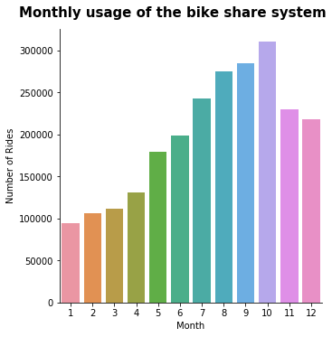

```python
#[This may take a while]
# monthly ridership usage
img_num = 1
g = sns.catplot(data=df_copy, x='start_time_month', kind='count')
g.set_axis_labels("Month", "Number of Rides")
g.fig.suptitle('Monthly usage of the bike share system', y=1.03, fontsize=15, fontweight='semibold');
if create_graph_img == True:
    create_graph_imgplt.savefig(img_dir+ str(img_num)+'_Univariate_member_age.png');
```

**observation**: October is the month with the highest bike share usage. Living in the bay area I can attest that the month of October is a nice month to visit the San Francisco area because is clear of fog. Notice there is a considerable drop in ridership after December as the new year kicks in and it pickup faster for the summer months.

Now that we know October is the month with the highest ridership, let look at the monthly trends.

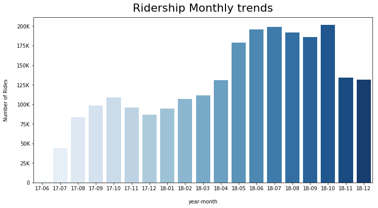

```python
# Ridership Monthly trends
plt.figure(figsize=(12,6))
sns.countplot(x='start_time_year_month_new', palette="Blues", data=df_copy.sort_values(by='start_time_year_month_new'))
plt.title('Ridership Monthly trends', fontsize=22, y=1.015)
plt.xlabel('year-month', labelpad=16)
plt.ylabel('Number of Rides', labelpad=16)
ax = plt.gca()
ax.yaxis.set_major_formatter(tick.FuncFormatter(change_axis_format))
img_num+=1
if create_graph_img == True:
    plt.savefig(img_dir+ str(img_num)+'_Univariate_ridership_trends.png');
```

**Observation** The graph shows and impressive grown among ridership with an increase during the summer months.

Next, lets look at the rider's age in more detail. I am interesting in capturing which age group has the most ridership.

```python
# Display the members average age
df_copy['member_age'].mean()
```

```
33.67697901461806
```

```python
# Source: https://seaborn.pydata.org/_images/color_palettes_6_0.png
# setup graph color
plot_color = sns.color_palette()[0] # blue color
```

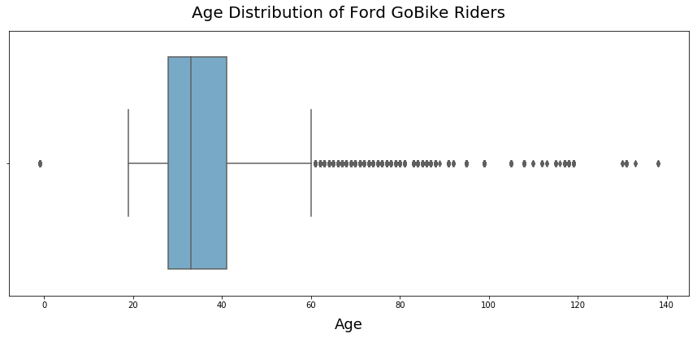

```python
# Generate a boxplot to show the age group with the highest ridership
plt.figure(figsize=(15,6))
sns.boxplot(x='member_age', data=df_copy, palette='Blues', orient='h',color=plot_color)
plt.title("Age Distribution of Ford GoBike Riders", fontsize=20, y=1.03)
plt.xlabel("Age", fontsize=18, labelpad=10)
#plt.savefig('image01.png');
img_num+=1
if create_graph_img == True:
    plt.savefig(img_dir+ str(img_num)+'_Univariate_member_age.png');
```

**Observation** As this boxplot shows, it is clear that most riders age group is between 28 and 41 years old.

Next lets look at the number of riders that used the service by age group on a monthly basis.

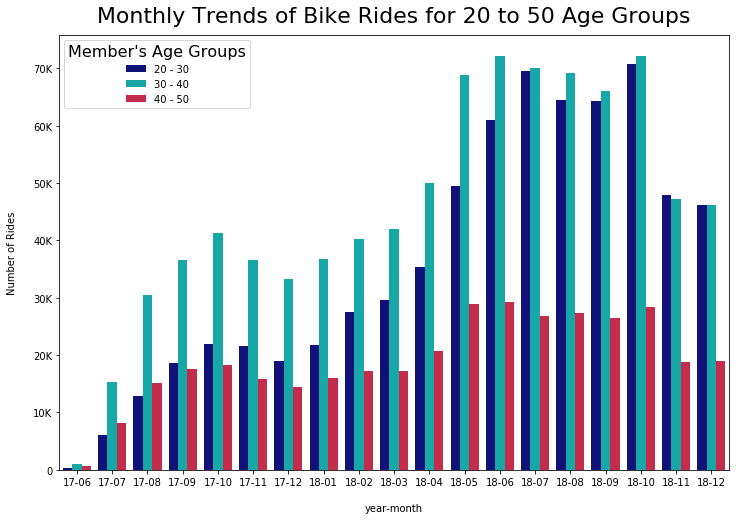

```python
# Monthly trend of bike rides for 20 to 50 years olds
# Reference: https://matplotlib.org/examples/color/named_colors.html
plt.figure(figsize=(12,8))
my_palette = {'20 - 30': 'darkblue', '30 - 40': 'c', '40 - 50': 'crimson'}
member_age_data = df_copy[df_copy['member_age_range'].isin(['20 - 30', '30 - 40', '40 - 50'])].sort_values(by=['start_time_year_month_new', 'member_age_range'])
ax = sns.countplot(x='start_time_year_month_new', hue='member_age_range', palette=my_palette, data=member_age_data)
plt.title('Monthly Trends of Bike Rides for 20 to 50 Age Groups', fontsize=22, y=1.015)
plt.xlabel('year-month', labelpad=16)
plt.ylabel('Number of Rides', labelpad=16)
leg = ax.legend()
leg.set_title("Member's Age Groups",prop={'size':16})
ax = plt.gca()
ax.yaxis.set_major_formatter(tick.FuncFormatter(change_axis_format))
img_num+=1
if create_graph_img == True:
    plt.savefig(img_dir+ str(img_num)+'_monthly_trends_member_age_range.png');
```

Now lets take a look at which hour of the day riders are most active.

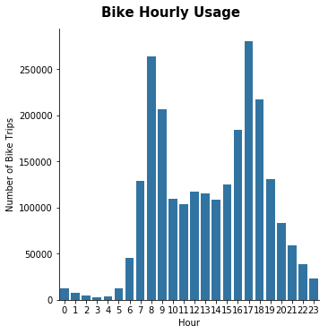

```python
# Bike Hourly Usage
g = sns.catplot(data=df_copy, x='start_time_hour', kind='count', color = plot_color)
g.set_axis_labels("Hour", "Number of Bike Trips")
g.fig.suptitle('Bike Hourly Usage', y=1.03, fontsize=15, fontweight='semibold');
img_num+=1
if create_graph_img == True:
    plt.savefig(img_dir+ str(img_num)+'_bike_hourly_usage.png');
```

**Observation**: This pattern is consistent with Bay area commuting times. As a Bay Area commuter myself, commute times peak the highest at around 7am and 5pm, therefore, bike ridership peaks at 8am and 5pm during rush hour.

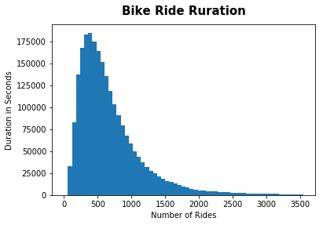

```python
# Bike Ride Ruration
bin_edges = np.arange(0, 3600,60)
plt.hist(data = df_copy, x = 'duration_sec', bins = bin_edges)
plt.title("Bike Ride Ruration", y=1.03, fontsize=15, fontweight='semibold')
plt.xlabel('Number of Rides')
plt.ylabel('Duration in Seconds');
img_num+=1
if create_graph_img == True:
    plt.savefig(img_dir+ str(img_num)+'_bike_ride_duration.png');
```

### Discuss the distribution(s) of your variable(s) of interest. Were there any unusual points? Did you need to perform any transformations?

Yes, the duration_sec variable gave me some trouble in that there were some values that were higher than 24 hours. The solution was to set the max range to 3600 seconds @ 60 minutes.

## Part V - Bivariate Exploration

Go Back To The Top

For this part of the project, we will explore the subscriber and non-subscribers of the bike sharing service. We will look at the different times both groups use the service.

```python
# Change color pallet for Bivariate
plot_color = sns.color_palette()[2] # Green
```

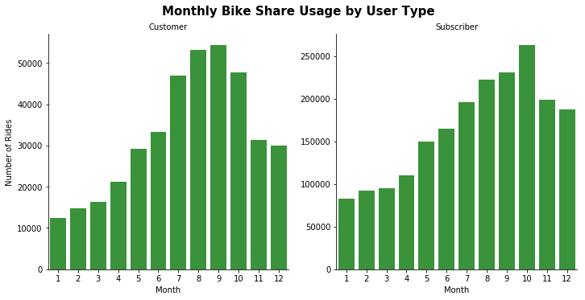

```python
# Monthly Bike Share Usage by User Type
g = sns.catplot(data=df_copy, x='start_time_month', col="user_type", kind='count', sharey = False, color = plot_color)
g.set_axis_labels("Month", "Number of Rides")
g.set_titles("{col_name}")
g.fig.suptitle('Monthly Bike Share Usage by User Type', y=1.03, fontsize=15, fontweight='semibold');
img_num+=1
if create_graph_img == True:
    plt.savefig(img_dir+ str(img_num)+'_Bivariate_monthly.png');
```

**Observation:** As mentioned before, personally, I think October is the best time to visit the San Francisco bay area. This time is also known as the "Indian Summer" by locals. The weather summer-like and pleasant due to the lack of fog in the city of San Franciso. In comparison with the two charts, locals seem to prefect October as the best month to bike ride for this reason. However, non-members peak in during the summer months which is consistent with tourism in the Bay Area.

Tourism is a big part of the economy in the Bay Area. Next lets look at which day of the week has the highest ridership.

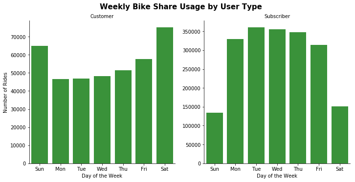

```python
# Weekly Bike Share Usage by User Type
days = [ 'Sun','Mon', 'Tue', 'Wed', 'Thu', 'Fri', 'Sat']
g = sns.catplot(data=df_copy, x='start_time_week_abbr', col="user_type", kind='count', sharey = False, color = plot_color, order = days)
g.set_axis_labels("Day of the Week", "Number of Rides")
g.set_titles("{col_name}")
g.fig.suptitle('Weekly Bike Share Usage by User Type', y=1.03, fontsize=15, fontweight='semibold');
img_num+=1
if create_graph_img == True:
    plt.savefig(img_dir+ str(img_num)+'_Bivariate_weekly.png');
```

**Observation:** Ridership for Subscribers appear to be highest during weekdays (Monday - Friday) This indicates that subscribers are locals who use the service for commuting to and from work. Also the number is subscribers is substantially higher than non-subscribers.

For Non-Subscribers, the weekends are the highest usage which indicates tourists.

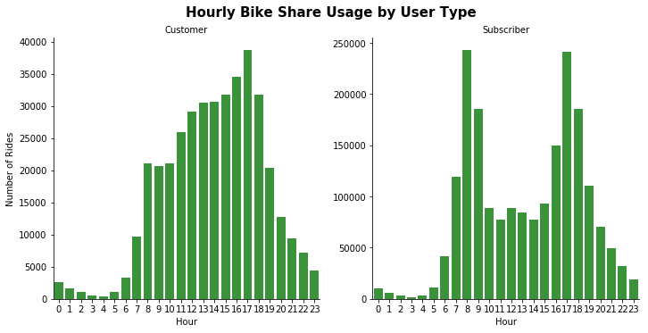

```python
# Hourly Bike Share Usage by User Type
g = sns.catplot(data=df_copy, x='start_time_hour', col="user_type", kind='count', sharey = False, color = plot_color)
g.set_axis_labels("Hour", "Number of Rides")
g.set_titles("{col_name}")
g.fig.suptitle('Hourly Bike Share Usage by User Type', y=1.03, fontsize=15, fontweight='semibold');
img_num+=1
if create_graph_img == True:
    plt.savefig(img_dir+ str(img_num)+'_Bivariate_hourly.png');
```

**Observation:** Ridership for Subscribers appear to be highest during commute hours of 8am and 5pm. While non-subscribers start to pickup at 7am and whine down around 7pm.

Next, lets look at the duration of the service for each user.

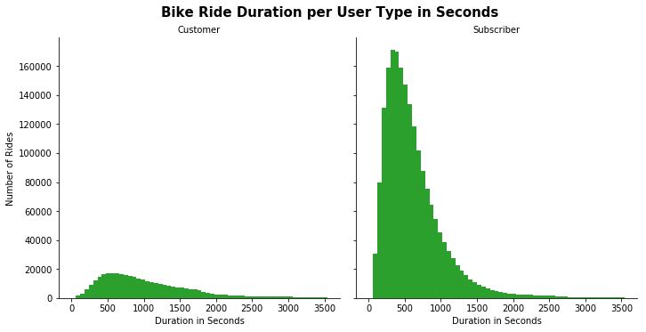

```python
# Bike Ride Duration per User Type in Seconds
g = sns.FacetGrid(df_copy, col="user_type", margin_titles=True, size=5)
bin_edges = np.arange(0, 3600,60)
g.map(plt.hist, "duration_sec", color=plot_color, bins=bin_edges)
g.set_axis_labels("Duration in Seconds", "Number of Rides")
g.set_titles(col_template = '{col_name}')
g.fig.suptitle('Bike Ride Duration per User Type in Seconds', y=1.03, fontsize=15, fontweight='semibold');
img_num+=1
if create_graph_img == True:
    plt.savefig(img_dir+ str(img_num)+'_Bivariate_seconds.png');
```

## Part VI - Multivariate Exploration

Go Back To The Top

In this section I will further explore the dataset by adding gender to the customer type and check the hourly distribution of bike rides during weekdays for customers and subscribers.

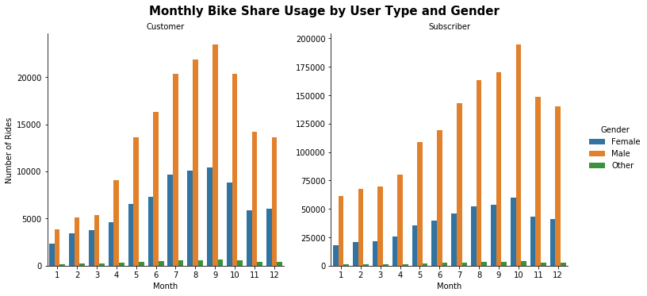

```python
# Monthly Bike Share Usage by User Type and Gender
g = sns.catplot(data=df_copy, x='start_time_month', col="user_type", hue="member_gender", kind='count', sharey = False)
g.set_axis_labels("Month", "Number of Rides")
g._legend.set_title('Gender')
g.set_titles("{col_name}")
g.fig.suptitle('Monthly Bike Share Usage by User Type and Gender', y=1.03, fontsize=15, fontweight='semibold');
img_num+=1
if create_graph_img == True:
    plt.savefig(img_dir+ str(img_num)+'_Multivariate_monthly.png');
```

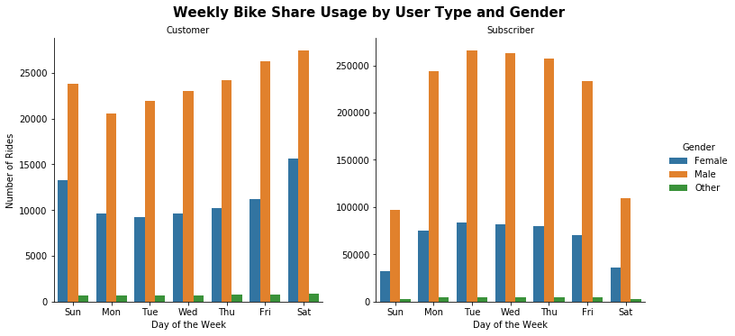

```python
# Weekly Bike Share Usage by User Type and Gender
days = ['Sun', 'Mon', 'Tue', 'Wed', 'Thu', 'Fri', 'Sat']
g = sns.catplot(data=df_copy, x='start_time_week_abbr', col="user_type", hue='member_gender', kind='count', sharey = False, order = days)
g.set_axis_labels("Day of the Week", "Number of Rides")
g._legend.set_title('Gender')
g.set_titles("{col_name}")
g.fig.suptitle('Weekly Bike Share Usage by User Type and Gender', y=1.03, fontsize=15, fontweight='semibold');
img_num+=1
if create_graph_img == True:
    plt.savefig(img_dir+ str(img_num)+'_Multivariate_weekly.png');
```

**Observation** For member riders, Monday through Friday are the highest usage. This is due to the flexibility the bike sharing service offers to riders who need to take short trips to and from work. It is surprising to see the males use the service much more than females.

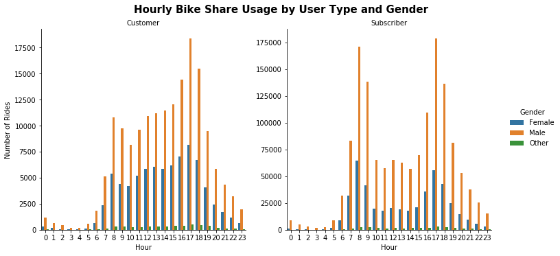

```python
# Hourly Bike Share Usage by User Type and Gender
g = sns.catplot(data=df_copy, x='start_time_hour', col="user_type", hue='member_gender', kind='count', sharey = False)
g.set_axis_labels("Hour", "Number of Rides")
g._legend.set_title('Gender')
g.set_titles("{col_name}")
g.fig.suptitle('Hourly Bike Share Usage by User Type and Gender', y=1.03, fontsize=15, fontweight='semibold');
img_num+=1
if create_graph_img == True:
    plt.savefig(img_dir+ str(img_num)+'_Multivariate_hourly.png');
```

**Observation** These charts are consisten with the previous charts in that ridership peaks during rush hour for both user and gender types. Again, ridership is greater for male riders than female.

[figure not shown]

```python
# Generate Hourly Usage and Frequency for 20-50 Age Group Heat Map
subscriber_hour_df = df_copy[(df_copy['member_age']>=20) & (df_copy['member_age']<50)
                              &(df_copy['start_time_hour']>5)&(df_copy['user_type']=='Subscriber')
                             ].groupby(['start_time_week_abbr', 'start_time_hour']).agg({'bike_id' : 'count'}).rename(columns={'bike_id':'count'}).reset_index()
subscriber_hour_df['start_time_week_abbr'] = pd.Categorical(subscriber_hour_df['start_time_week_abbr'], categories=[ 'Sun','Mon','Tue','Wed','Thu','Fri','Sat'], ordered=True)
subscriber_hour_df['count_perc'] = subscriber_hour_df['count'].apply(lambda x: (x/subscriber_hour_df['count'].sum())*100)
subscriber_hour_df['rank'] = subscriber_hour_df['count_perc'].rank(ascending=False).astype(int)
subscriber_hour_df_pivoted = subscriber_hour_df.pivot_table(index='start_time_hour', columns='start_time_week_abbr', values='rank')
customer_hour_df = df_copy[(df_copy['member_age']>=20) & (df_copy['member_age']<40)
                              &(df_copy['start_time_hour']>5)&(df_copy['user_type']=='Customer')
                             ].groupby(['start_time_week_abbr', 'start_time_hour']).agg({'bike_id' : 'count'}).rename(columns={'bike_id':'count'}).reset_index()
customer_hour_df['start_time_week_abbr'] = pd.Categorical(customer_hour_df['start_time_week_abbr'], categories=['Mon','Tue','Wed','Thu','Fri','Sat', 'Sun'], ordered=True)
customer_hour_df['count_perc'] = customer_hour_df['count'].apply(lambda x: (x/customer_hour_df['count'].sum())*100) #male
customer_hour_df['rank'] = customer_hour_df['count_perc'].rank(ascending=False).astype(int)
customer_hour_df_pivoted = customer_hour_df.pivot_table(index='start_time_hour', columns='start_time_week_abbr', values='rank').astype(int)
plt.figure(figsize=(15,10))
plt.subplot(121)
plt.suptitle('Hourly Usage and Frequency for 20-50 Age Group', fontsize=22)
sns.heatmap(subscriber_hour_df_pivoted, fmt='d', annot=True, cmap='YlGnBu_r', annot_kws={"size": 12})
plt.title("Subscribers Bike Usage", y=1.015)
plt.xlabel('Day of the Week', labelpad=15)
plt.ylabel('Hour (Military)', labelpad=15)
plt.yticks(rotation=360)
plt.subplot(122)
sns.heatmap(customer_hour_df_pivoted, fmt='d', annot=True, cmap='YlGnBu_r', annot_kws={"size": 12}, cbar_kws={'label': 'Frequency Ranking'})
plt.title("Customers Bike Usage", y=1.015)
plt.xlabel('Day of the Week', labelpad=15)
plt.ylabel(' ')
plt.yticks(rotation=360)
img_num+=1
if create_graph_img == True:
    plt.savefig(img_dir+ str(img_num)+'_Multivariate_seconds.png');
```

**Observation** This heat chars shows the differences between both group types and their riding habits. Subscribers ridership trends peak during weekdays, while customers peak during Satuday and Sunday.

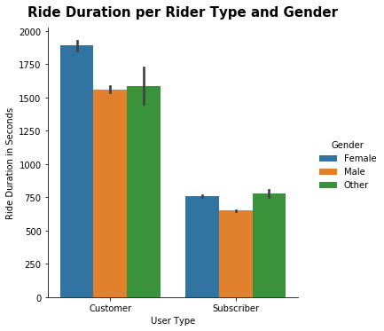

```python
# Ride Duration per Rider Type and Gender
g = sns.catplot(data=df_copy, x='user_type', y="duration_sec", hue="member_gender", kind="bar")
g.set_axis_labels("User Type", "Ride Duration in Seconds")
g._legend.set_title('Gender')
g.fig.suptitle('Ride Duration per Rider Type and Gender', y=1.03, fontsize=15, fontweight='semibold');
img_num+=1
if create_graph_img == True:
    plt.savefig(img_dir+ str(img_num)+'_Multivariate_seconds.png');
```

**Observation** Non-subscriber female riders appear to take longer bike trips. While members trip time is about the same.

### Talk about some of the relationships you observed in this part of the investigation. Were there features that strengthened each other in terms of looking at your feature(s) of interest?

> ne interesting relationship I found was the weekday peak times. The data showed that members are using the service effectively during commute hours. Having to travel to the Bay Area during peak commute hours is an unpleasant experience. This bike sharing services provides a very convenient way to travel short distances during commute hours.

### Were there any interesting or surprising interactions between features?

> It was interesting to find that the 30-40 age group has the highest ridership. I was expecting the newer generation to have the most usage because of economics and the proliferation of technology amonth younger riders.

## Conclusions

Go Back To The Top

I thought this was going to be a straight forward and simple project based on all that I have learned from the previous projects. However, as I dived in deeper I came across some challenges with the syntax. Through patience and perseverance I was able to find the answers on-line with my friends google and stackoverflow.

The data that was provided by the GoBike System seem to be an accurate usage representation of local commuters and tourists. I was able to learn that bike usage peak during commute hours for members, yet for non-member which are identified as tourist peak days seem to be during the weekend on Saturday and Sundays.

Another interesting piece of information I was able confirm during my observations is for the month of October. The San Francisco bay area is unique in that most of the year is foggy. However, during the month of October, we can enjoy fog-free weather and thus the best time to bike at golden gate park. With the bike share data, you can confirm that October has the highest ridership from any month of the year.

Overall this was a challenging project, but I learned alot from the research. I enjoyed it because I was able to related with the local area. I first visited the bay area in 2000. My co-workers invited me to visit. I felt in love with the Bay Area and I found a way to transfer from Denver. I've been living in the Bay Area for more than 19 years now and its an amazing place to live. Please don't take my word for it, I invite you to visit and see for yourself.

## Resources

Go Back To The Top

- [Ford GoBike System (Lyft)](https://www.fordgobike.com/)
- [PyData](https://pydata.org)
- [Pandas:Python Data Analysis Library](https://pandas.pydata.org)
- [Stackoverflow](https://stackoverflow.com)
- [Programiz](https://www.programiz.com)
- [Google](https://www.google.com)
- [Udacity](https://www.udacity.com)
- [Matplotlib](https://matplotlib.org)
- [Baywheels](https://help.baywheels.com/hc/en-us/articles/360029362511-Usage-Fees)

Go Back To The Top